# 重賞レース予測レポート【毎時自動更新中】

作成日時: 2026/09/27 16:05:41

☞ [マニュアル(pdf)](https://ryutoro-galois.github.io/keiba-predictor/manual/manual.pdf)

☞ 過去6年の同一レース結果: [2025年](https://ryutoro-galois.github.io/keiba-predictor/report/PredResult_2025y_raceDate_20250927_20250928.html), [2024年](https://ryutoro-galois.github.io/keiba-predictor/report/PredResult_2024y_raceDate_20240928_20240929.html), [2023年](https://ryutoro-galois.github.io/keiba-predictor/report/PredResult_2023y_raceDate_20230930_20231001.html), [2022年](https://ryutoro-galois.github.io/keiba-predictor/report/PredResult_2022y_raceDate_20221001_20221002.html), [2021年](https://ryutoro-galois.github.io/keiba-predictor/report/PredResult_2021y_raceDate_20211002_20211003.html), [2020年](https://ryutoro-galois.github.io/keiba-predictor/report/PredResult_2020y_raceDate_20201003_20201004.html)

☞ 過去4週間の別レース結果: [1週前(9/19-21)](https://ryutoro-galois.github.io/keiba-predictor/report/PredResult_2026y_raceDate_20260919_20260921.html), [2週前(9/12-13)](https://ryutoro-galois.github.io/keiba-predictor/report/PredResult_2026y_raceDate_20260912_20260913.html), [3週前(9/5-6)](https://ryutoro-galois.github.io/keiba-predictor/report/PredResult_2026y_raceDate_20260905_20260906.html), [4週前(8/30)](https://ryutoro-galois.github.io/keiba-predictor/report/PredResult_2026y_raceDate_20260830_20260830.html)

☞ netkeiba: [シリウスステークス(GⅢ)](https://race.netkeiba.com/race/shutuba.html?race_id=202609040811&rf=race_list), [スプリンターズステークス(GⅠ)](https://race.netkeiba.com/race/shutuba.html?race_id=202606040911&rf=race_list)

## 0. 推し馬予測 (AI予測)

### 【シリウスステークス(GⅢ) 2026/09/26(土)】

- 本命(◎): 1-3着内確率(勝負強さ)が1位の馬
- 対抗(◯): 1-3着内確率が2-N位(20%程度以上)の中で予測タイムが最も速い馬
- 3番手(▲): 1-3着内確率が2-N位(20%程度以上)のでダークホース確率が最も高い馬
- 穴: ダークホース確率が上位1-M位(40%程度以上)の中で1-3着内確率が最も高い馬

| 推し馬 | 枠番 | 馬番 | 人気 | オッズ | 馬名 | 騎手 | 調教師 | 予測タイム(sec) | 1_順位 | 1-3着内確率(%) | 2_順位 | ﾀﾞｰｸﾎｰｽ確率(%) | 3_順位 |
| --- | --- | --- | --- | --- | --- | --- | --- | --- | --- | --- | --- | --- | --- |
| 本命(◎) | 3 | 6 | 2 | 4.5 | ギュルヴィ | 武豊 | 大久保龍志 | 121.5 | 2 | 54.0 | 1 | 0.7 | 14 |
| 対抗(◯) | 7 | 13 | 1 | 3.6 | ラムジェット | 三浦皇成 | 松永幹夫 | 121.5 | 2 | 20.5 | 2 | 0.4 | 16 |
| 3番手(▲) | 4 | 7 | 15 | 70.1 | ミッキークレスト | 酒井学 | 大久保龍志 | 130.7 | 6 | 10.6 | 6 | 69.1 | 1 |
| 穴 | 2 | 3 | 9 | 17.5 | メイショウズイウン | 石橋脩 | 本田優 | 130.5 | 5 | 14.1 | 5 | 42.4 | 3 |

### 【スプリンターズステークス(GⅠ) 2026/09/27(日)】

- 本命(◎): 1-3着内確率(勝負強さ)が1位の馬
- 対抗(◯): 1-3着内確率が2-N位(20%程度以上)の中で予測タイムが最も速い馬
- 3番手(▲): 1-3着内確率が2-N位(20%程度以上)のでダークホース確率が最も高い馬
- 穴: ダークホース確率が上位1-M位(40%程度以上)の中で1-3着内確率が最も高い馬

| 推し馬 | 枠番 | 馬番 | 人気 | オッズ | 馬名 | 騎手 | 調教師 | 予測タイム(sec) | 1_順位 | 1-3着内確率(%) | 2_順位 | ﾀﾞｰｸﾎｰｽ確率(%) | 3_順位 |
| --- | --- | --- | --- | --- | --- | --- | --- | --- | --- | --- | --- | --- | --- |
| 本命(◎) | 1 | 2 | 15 | 56.1 | アイサンサン | 幸英明 | 橋田宜長 | 70.4 | 7 | 37.5 | 1 | 68.6 | 3 |
| 対抗(◯) | 7 | 13 | 2 | 3.9 | パンジャタワー | 松山弘平 | 橋口慎介 | 66.7 | 2 | 23.6 | 3 | 1.5 | 14 |
| 3番手(▲) | 2 | 3 | 7 | 16.1 | ママコチャ | 武豊 | 池江泰寿 | 67.1 | 5 | 26.9 | 2 | 2.6 | 9 |
| 穴 | 1 | 1 | 14 | 52.3 | レッドモンレーヴ | 酒井学 | 蛯名正義 | 75.7 | 14 | 15.4 | 8 | 71.5 | 1 |

## 1. 予測チャート (タイム/勝負強さ)

### 【シリウスステークス(GⅢ)】

2026/09/26(土), 09_阪神, ダ右2000m

[interactive chart not shown]

### 【スプリンターズステークス(GⅠ)】

2026/09/27(日), 06_中山, 芝右外1200m

[interactive chart not shown]

## 2. オッズモニタリング (毎時)

### 【シリウスステークス】

[interactive chart not shown]

### 【スプリンターズステークス】

[interactive chart not shown]

## 3. 出馬表

### 【シリウスステークス 2026/09/26(土) 】

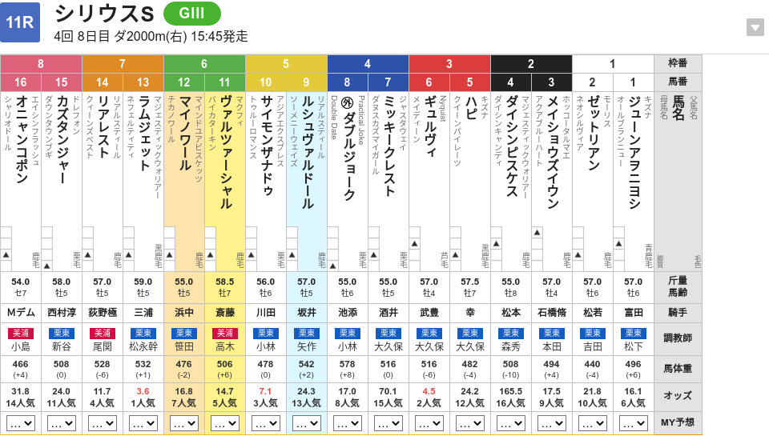

### 【スプリンターズステークス 2026/09/27(日) 】

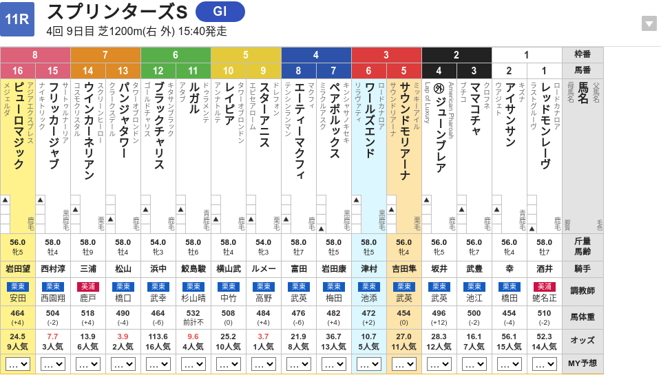

## 4. 単勝予測結果

### 【シリウスステークス(GⅢ) 2026/09/26(土)】

| 枠番 | 馬番 | 人気 | オッズ | 馬名 | 騎手 | 調教師 | 予測タイム(sec) | 1_順位 | 1-3着内確率(%) | 2_順位 | ﾀﾞｰｸﾎｰｽ確率(%) | 3_順位 |
| --- | --- | --- | --- | --- | --- | --- | --- | --- | --- | --- | --- | --- |
| 1 | 1 | 6 | 16.1 | ジューンアヲニヨシ | 富田暁 | 松下武士 | 131.6 | 7 | 14.5 | 4 | 1.4 | 9 |
| 1 | 2 | 10 | 21.8 | ゼットリアン | 松若風馬 | 吉田直弘 | 134.7 | 13 | 5.5 | 11 | 38.4 | 4 |
| 2 | 3 | 9 | 17.5 | メイショウズイウン | 石橋脩 | 本田優 | 130.5 | 5 | 14.1 | 5 | 42.4 | 3 |
| 2 | 4 | 16 | 165.5 | ダイシンピスケス | 松本大輝 | 森秀行 | 136.3 | 14 | 2.3 | 15 | 16.0 | 8 |
| 3 | 5 | 12 | 24.2 | ハピ | 幸英明 | 大久保龍志 | 130.1 | 4 | 5.4 | 12 | 44.5 | 2 |
| 3 | 6 | 2 | 4.5 | ギュルヴィ | 武豊 | 大久保龍志 | 121.5 | 2 | 54.0 | 1 | 0.7 | 14 |
| 4 | 7 | 15 | 70.1 | ミッキークレスト | 酒井学 | 大久保龍志 | 130.7 | 6 | 10.6 | 6 | 69.1 | 1 |
| 4 | 8 | 8 | 17.0 | ダブルジョーク | 池添謙一 | 小林真也 | 133.1 | 9 | 5.4 | 13 | 0.8 | 13 |
| 5 | 9 | 13 | 24.3 | ルシュヴァルドール | 坂井瑠星 | 矢作芳人 | 131.9 | 8 | 4.9 | 14 | 18.1 | 7 |
| 5 | 10 | 3 | 7.1 | サイモンザナドゥ | 川田将雅 | 小林真也 | 134.5 | 12 | 16.5 | 3 | 0.5 | 15 |

[output cut: 6 more lines]

### 【スプリンターズステークス(GⅠ) 2026/09/27(日)】

| 枠番 | 馬番 | 人気 | オッズ | 馬名 | 騎手 | 調教師 | 予測タイム(sec) | 1_順位 | 1-3着内確率(%) | 2_順位 | ﾀﾞｰｸﾎｰｽ確率(%) | 3_順位 |
| --- | --- | --- | --- | --- | --- | --- | --- | --- | --- | --- | --- | --- |
| 1 | 1 | 14 | 52.3 | レッドモンレーヴ | 酒井学 | 蛯名正義 | 75.7 | 14 | 15.4 | 8 | 71.5 | 1 |
| 1 | 2 | 15 | 56.1 | アイサンサン | 幸英明 | 橋田宜長 | 70.4 | 7 | 37.5 | 1 | 68.6 | 3 |
| 2 | 3 | 7 | 16.1 | ママコチャ | 武豊 | 池江泰寿 | 67.1 | 5 | 26.9 | 2 | 2.6 | 9 |
| 2 | 4 | 12 | 28.3 | ジューンブレア | 坂井瑠星 | 武英智 | 66.8 | 4 | 11.0 | 11 | 54.3 | 5 |
| 3 | 5 | 11 | 27.0 | サウンドモリアーナ | 吉田隼人 | 武英智 | 76.8 | 16 | 3.6 | 16 | 20.5 | 7 |
| 3 | 6 | 5 | 10.7 | ワールズエンド | 津村明秀 | 池添学 | 68.4 | 6 | 13.7 | 9 | 2.1 | 10 |
| 4 | 7 | 13 | 36.7 | ペアポルックス | 岩田康誠 | 梅田智之 | 75.2 | 10 | 12.1 | 10 | 57.9 | 4 |
| 4 | 8 | 8 | 21.9 | エーティーマクフィ | 富田暁 | 武英智 | 75.4 | 11 | 5.7 | 14 | 1.8 | 12 |
| 5 | 9 | 1 | 3.7 | スターアニス | Ｃ．ルメール | 高野友和 | 66.7 | 2 | 20.9 | 5 | 1.4 | 15 |
| 5 | 10 | 10 | 25.2 | レイピア | 横山武史 | 中竹和也 | 73.9 | 8 | 8.9 | 13 | 43.6 | 6 |

[output cut: 6 more lines]

## 5. 人気と着順の乖離率推移

### 【シリウスステークス_1997y_2019y】

[interactive chart not shown]

### 【スプリンターズステークス_1990y_2019y】

[interactive chart not shown]

### 【シリウスステークス_1997y_2019y】

| No | 開催年 | 不整合率(%) | 頭数 | 人気別着順(1-3位) | 人気別着順(全体) |
| --- | --- | --- | --- | --- | --- |
| 23 | 2019 | 55.2 | 14頭 | 6-7-5 | 6\|7\|5\|3\|10\|1\|13\|14\|2\|9\|11\|4\|8\|12 |
| 22 | 2018 | 45.4 | 16頭 | 2-7-3 | 2\|7\|3\|8\|12\|9\|14\|4\|6\|16\|1\|10\|13\|5\|11\|15 |
| 21 | 2017 | 48.0 | 16頭 | 11-5-3 | 11\|5\|3\|7\|10\|13\|1\|2\|6\|9\|4\|15\|8\|12\|16\|14 |
| 20 | 2016 | 13.5 | 11頭 | 1-2-4 | 1\|2\|4\|5\|6\|10\|11\|3\|9\|7\|8 |
| 19 | 2015 | 34.4 | 12頭 | 3-1-2 | 3\|1\|2\|12\|10\|8\|4\|6\|9\|11\|5\|7 |
| 18 | 2014 | 29.6 | 14頭 | 1-3-7 | 1\|3\|7\|5\|6\|8\|14\|13\|2\|4\|12\|9\|11\|10 |
| 17 | 2013 | 62.9 | 15頭 | 5-3-6 | 5\|3\|6\|2\|13\|7\|4\|8\|15\|9\|10\|14\|16\|12\|1 |
| 16 | 2012 | 37.6 | 16頭 | 2-3-1 | 2\|3\|1\|11\|10\|8\|9\|5\|4\|15\|7\|14\|13\|16\|12\|6 |
| 15 | 2011 | 49.1 | 12頭 | 5-4-2 | 5\|4\|2\|1\|9\|6\|10\|7\|12\|3\|11\|8 |
| 14 | 2010 | 34.3 | 12頭 | 1-4-9 | 1\|4\|9\|10\|3\|5\|2\|8\|11\|6\|7\|12 |

[output cut: 13 more lines]

### 【スプリンターズステークス_1990y_2019y】

| No | 開催年 | 不整合率(%) | 頭数 | 人気別着順(1-3位) | 人気別着順(全体) |
| --- | --- | --- | --- | --- | --- |
| 30 | 2019 | 37.9 | 16頭 | 2-3-1 | 2\|3\|1\|6\|9\|12\|13\|14\|5\|11\|10\|8\|4\|15\|16\|7 |
| 29 | 2018 | 35.5 | 15頭 | 1-11-13 | 1\|11\|13\|10\|4\|3\|2\|12\|15\|5\|16\|8\|7\|6\|14 |
| 28 | 2017 | 24.3 | 16頭 | 1-5-7 | 1\|5\|7\|16\|12\|8\|2\|9\|13\|14\|3\|6\|10\|11\|4\|15 |
| 27 | 2016 | 56.9 | 16頭 | 3-2-9 | 3\|2\|9\|5\|12\|8\|14\|16\|7\|11\|6\|1\|10\|15\|4\|13 |
| 26 | 2015 | 41.7 | 15頭 | 1-11-9 | 1\|11\|9\|4\|3\|6\|12\|15\|8\|7\|14\|5\|2\|10\|13 |
| 25 | 2014 | 54.9 | 18頭 | 13-2-5 | 13\|2\|5\|4\|10\|15\|9\|6\|14\|17\|7\|3\|1\|11\|16\|12\|8\|18 |
| 24 | 2013 | 18.9 | 16頭 | 1-2-15 | 1\|2\|15\|6\|10\|5\|3\|9\|13\|16\|4\|11\|8\|12\|14\|7 |
| 23 | 2012 | 23.2 | 16頭 | 2-1-9 | 2\|1\|9\|3\|8\|11\|13\|4\|15\|5\|12\|7\|16\|10\|14\|6 |
| 22 | 2011 | 46.5 | 15頭 | 3-9-7 | 3\|9\|7\|1\|4\|6\|5\|8\|13\|10\|2\|15\|14\|11\|12 |
| 21 | 2010 | 55.1 | 16頭 | 10-3-7 | 10\|3\|7\|6\|2\|8\|1\|13\|11\|4\|14\|15\|9\|5\|12\|16 |

[output cut: 20 more lines]

## 6. 1-3番人気馬の着順分類予測

### 【シリウスステークス】

| 分類 | 凡例 | 発生確率(%) | 当該レース | 当該レースランク | 直近1年間 |
| --- | --- | --- | --- | --- | --- |
| 8: 1,2,3番人気すべて着外 (8_darkhorse) | * \| * \| * | 18.1 | 0.66 | 0.66 | 0.36 |
| 1: 1番人気のみ (1_pop1) | 1 \| * \| * | 17.7 | 1.03 | 1.03 | 0.00 |
| 4: 1,2番人気のみ (4_pop12) | 1 \| 2 \| * | 17.5 | 1.02 | 1.02 | 0.00 |
| 5: 1,3番人気のみ (5_pop13) | 1 \| 3 \| * | 13.0 | 1.88 | 1.88 | 0.00 |
| 6: 2,3番人気のみ (6_pop23) | 2 \| 3 \| * | 9.7 | 1.41 | 1.41 | 0.00 |
| 2: 2番人気のみ (2_pop2) | 2 \| * \| * | 9.0 | 2.65 | 2.65 | 0.00 |
| 3: 3番人気のみ (3_pop3) | 3 \| * \| * | 8.2 | 0.59 | 0.59 | 0.00 |
| 7: 1,2,3番人気すべて着内 (7_pop123) | 1 \| 2 \| 3 | 6.9 | 1.00 | 1.00 | 0.14 |

### 【スプリンターズステークス】

| 分類 | 凡例 | 発生確率(%) | 当該レース | 当該レースランク | 直近1年間 |
| --- | --- | --- | --- | --- | --- |
| 8: 1,2,3番人気すべて着外 (8_darkhorse) | * \| * \| * | 18.1 | 3.23 | 3.23 | 0.00 |
| 1: 1番人気のみ (1_pop1) | 1 \| * \| * | 17.7 | 0.91 | 0.91 | 0.00 |
| 4: 1,2番人気のみ (4_pop12) | 1 \| 2 \| * | 17.5 | 0.90 | 0.90 | 0.00 |
| 5: 1,3番人気のみ (5_pop13) | 1 \| 3 \| * | 13.0 | 2.32 | 2.32 | 0.00 |
| 6: 2,3番人気のみ (6_pop23) | 2 \| 3 \| * | 9.7 | 1.73 | 1.73 | 0.00 |
| 2: 2番人気のみ (2_pop2) | 2 \| * \| * | 9.0 | 1.08 | 1.08 | 0.00 |
| 3: 3番人気のみ (3_pop3) | 3 \| * \| * | 8.2 | 1.46 | 1.46 | 0.00 |
| 7: 1,2,3番人気すべて着内 (7_pop123) | 1 \| 2 \| 3 | 6.9 | 0.23 | 0.23 | 0.07 |

## 7. 3連複予測結果

### 【シリウスステークス(GⅢ) 2026/09/26(土)】

| 分類 | 馬番 | 枠番 | 人気 | 平均予測タイム(sec) | 1-3着内確率(%) | ﾀﾞｰｸﾎｰｽ確率(%) | 馬名 | 騎手 | 調教師 |
| --- | --- | --- | --- | --- | --- | --- | --- | --- | --- |
| 7: 1,2,3番人気すべて着内 (7_pop123) | 13-6-10 | 7-3-5 | 1-2-3 | 125.83 | 1.83 | 0.00 | ラムジェット \| ギュルヴィ \| サイモンザナドゥ | 三浦皇成 \| 武豊 \| 川田将雅 | 松永幹夫 \| 大久保龍志 \| 小林真也 |
| 4: 1,2番人気のみ (4_pop12) | 13-6-1 | 7-3-1 | 1-2-6 | 124.87 | 1.61 | 0.00 | ラムジェット \| ギュルヴィ \| ジューンアヲニヨシ | 三浦皇成 \| 武豊 \| 富田暁 | 松永幹夫 \| 大久保龍志 \| 松下武士 |
| 4: 1,2番人気のみ (4_pop12) | 13-6-3 | 7-3-2 | 1-2-9 | 124.50 | 1.57 | 0.00 | ラムジェット \| ギュルヴィ \| メイショウズイウン | 三浦皇成 \| 武豊 \| 石橋脩 | 松永幹夫 \| 大久保龍志 \| 本田優 |
| 6: 2,3番人気のみ (6_pop23) | 6-10-1 | 3-5-1 | 2-3-6 | 129.20 | 1.29 | 0.00 | ギュルヴィ \| サイモンザナドゥ \| ジューンアヲニヨシ | 武豊 \| 川田将雅 \| 富田暁 | 大久保龍志 \| 小林真也 \| 松下武士 |
| 6: 2,3番人気のみ (6_pop23) | 6-10-3 | 3-5-2 | 2-3-9 | 128.83 | 1.26 | 0.00 | ギュルヴィ \| サイモンザナドゥ \| メイショウズイウン | 武豊 \| 川田将雅 \| 石橋脩 | 大久保龍志 \| 小林真也 \| 本田優 |
| 4: 1,2番人気のみ (4_pop12) | 13-6-7 | 7-3-4 | 1-2-15 | 124.57 | 1.17 | 0.00 | ラムジェット \| ギュルヴィ \| ミッキークレスト | 三浦皇成 \| 武豊 \| 酒井学 | 松永幹夫 \| 大久保龍志 \| 大久保龍志 |
| 4: 1,2番人気のみ (4_pop12) | 13-6-14 | 7-3-7 | 1-2-4 | 126.87 | 1.17 | 0.00 | ラムジェット \| ギュルヴィ \| リアレスト | 三浦皇成 \| 武豊 \| 荻野極 | 松永幹夫 \| 大久保龍志 \| 尾関知人 |
| 2: 2番人気のみ (2_pop2) | 6-1-3 | 3-1-2 | 2-6-9 | 127.87 | 1.11 | 0.00 | ギュルヴィ \| ジューンアヲニヨシ \| メイショウズイウン | 武豊 \| 富田暁 \| 石橋脩 | 大久保龍志 \| 松下武士 \| 本田優 |
| 4: 1,2番人気のみ (4_pop12) | 13-6-11 | 7-3-6 | 1-2-5 | 125.50 | 0.98 | 0.00 | ラムジェット \| ギュルヴィ \| ヴァルツァーシャル | 三浦皇成 \| 武豊 \| 斎藤新 | 松永幹夫 \| 大久保龍志 \| 高木登 |
| 6: 2,3番人気のみ (6_pop23) | 6-10-7 | 3-5-4 | 2-3-15 | 128.90 | 0.94 | 0.00 | ギュルヴィ \| サイモンザナドゥ \| ミッキークレスト | 武豊 \| 川田将雅 \| 酒井学 | 大久保龍志 \| 小林真也 \| 大久保龍志 |

[output cut: 550 more lines]

### 【スプリンターズステークス(GⅠ) 2026/09/27(日)】

| 分類 | 馬番 | 枠番 | 人気 | 平均予測タイム(sec) | 1-3着内確率(%) | ﾀﾞｰｸﾎｰｽ確率(%) | 馬名 | 騎手 | 調教師 |
| --- | --- | --- | --- | --- | --- | --- | --- | --- | --- |
| 2: 2番人気のみ (2_pop2) | 13-3-2 | 7-2-1 | 2-7-15 | 68.07 | 2.38 | 0.03 | パンジャタワー \| ママコチャ \| アイサンサン | 松山弘平 \| 武豊 \| 幸英明 | 橋口慎介 \| 池江泰寿 \| 橋田宜長 |
| 8: 1,2,3番人気すべて着外 (8_darkhorse) | 14-3-2 | 7-2-1 | 6-7-15 | 71.30 | 2.16 | 0.03 | ウインカーネリアン \| ママコチャ \| アイサンサン | 三浦皇成 \| 武豊 \| 幸英明 | 鹿戸雄一 \| 池江泰寿 \| 橋田宜長 |
| 1: 1番人気のみ (1_pop1) | 9-3-2 | 5-2-1 | 1-7-15 | 68.07 | 2.11 | 0.02 | スターアニス \| ママコチャ \| アイサンサン | Ｃ．ルメール \| 武豊 \| 幸英明 | 高野友和 \| 池江泰寿 \| 橋田宜長 |
| 2: 2番人気のみ (2_pop2) | 13-14-2 | 7-7-1 | 2-6-15 | 71.17 | 1.90 | 0.02 | パンジャタワー \| ウインカーネリアン \| アイサンサン | 松山弘平 \| 三浦皇成 \| 幸英明 | 橋口慎介 \| 鹿戸雄一 \| 橋田宜長 |
| 4: 1,2番人気のみ (4_pop12) | 9-13-2 | 5-7-1 | 1-2-15 | 67.93 | 1.85 | 0.01 | スターアニス \| パンジャタワー \| アイサンサン | Ｃ．ルメール \| 松山弘平 \| 幸英明 | 高野友和 \| 橋口慎介 \| 橋田宜長 |
| 3: 3番人気のみ (3_pop3) | 15-3-2 | 8-2-1 | 3-7-15 | 70.63 | 1.69 | 0.02 | フリッカージャブ \| ママコチャ \| アイサンサン | 西村淳也 \| 武豊 \| 幸英明 | 西園翔太 \| 池江泰寿 \| 橋田宜長 |
| 1: 1番人気のみ (1_pop1) | 9-14-2 | 5-7-1 | 1-6-15 | 71.17 | 1.68 | 0.01 | スターアニス \| ウインカーネリアン \| アイサンサン | Ｃ．ルメール \| 三浦皇成 \| 幸英明 | 高野友和 \| 鹿戸雄一 \| 橋田宜長 |
| 8: 1,2,3番人気すべて着外 (8_darkhorse) | 11-3-2 | 6-2-1 | 4-7-15 | 70.97 | 1.61 | 0.03 | ルガル \| ママコチャ \| アイサンサン | 鮫島克駿 \| 武豊 \| 幸英明 | 杉山晴紀 \| 池江泰寿 \| 橋田宜長 |
| 8: 1,2,3番人気すべて着外 (8_darkhorse) | 3-1-2 | 2-1-1 | 7-14-15 | 71.07 | 1.56 | 1.27 | ママコチャ \| レッドモンレーヴ \| アイサンサン | 武豊 \| 酒井学 \| 幸英明 | 池江泰寿 \| 蛯名正義 \| 橋田宜長 |
| 6: 2,3番人気のみ (6_pop23) | 13-15-2 | 7-8-1 | 2-3-15 | 70.50 | 1.49 | 0.01 | パンジャタワー \| フリッカージャブ \| アイサンサン | 松山弘平 \| 西村淳也 \| 幸英明 | 橋口慎介 \| 西園翔太 \| 橋田宜長 |

[output cut: 550 more lines]

## 8. 直近の全レース情報

[output not shown]